# 結果 (Group 3)

## 実験データ

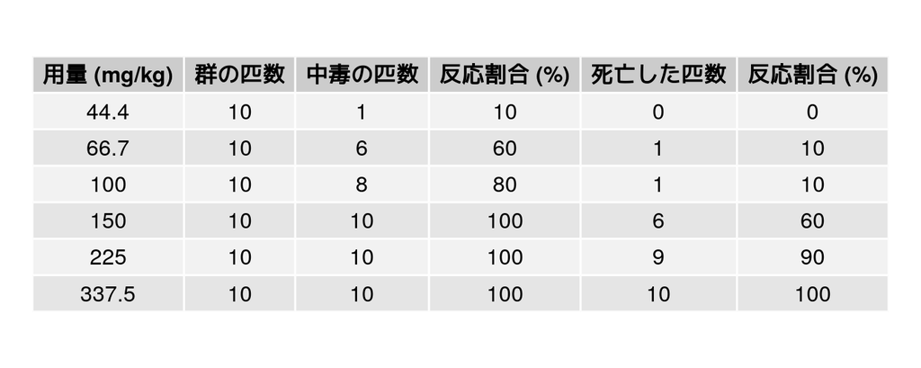

## あてはめ曲線

- 反応割合が0%あるいは100%のデータは使用せずに解析

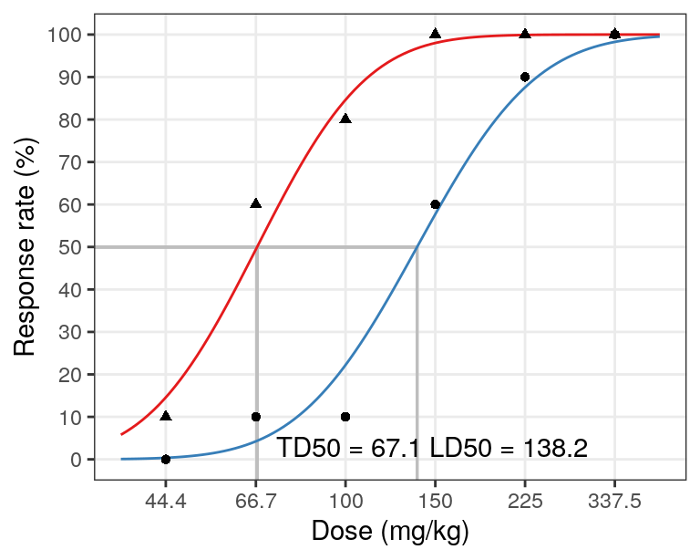

## TD<sub>50</sub>, LD<sub>50</sub>値および95%信頼区間

- TD<sub>50</sub> = 67.1 mg/kg （95%信頼区間 55.0-81.8）
- LD<sub>50</sub> = 138.2 mg/kg （95%信頼区間 113.1-168.8）

### （参考）95%信頼区間とは

実験の精度を示す指標であるという程度の理解で十分である。

- 信頼区間が狭いと実験の精度が良い
- 信頼区間が広いと実験の精度が悪い

また、95%信頼区間とは「真の値（この場合にはTD<sub>50</sub>およびLD<sub>50</sub>）が95%の確率でこの範囲に含まれている」ことを意味するのではない。

まず、「真の値（この場合にはTD<sub>50</sub>およびLD<sub>50</sub>であるが誰も真の値を知ることができない）がある」と考える。その上で1回実験を行い、95%信頼区間を求める。  
これと同じ実験を繰り返し行うと、（個体差などのサンプリング誤差のため）毎回異なる95%信頼区間が得られる。  
同じ実験を100回行って100個の95%信頼区間が得られた場合に、 95回分（すなわち95%）の95%信頼区間が真の値を含むというものである。

（戻る）